# Coastwide analysis of forestry impacts on BC Pacific Salmon

Apr. 2024

# 1 Overview

This short document provides some details on initial models fit and inferential outputs. It can be treated as a living appendix of sorts, and can be added to and polished over time.

Code and data to reproduce the analyses summarized in this document can be found in [**this repository**](https://github.com/Pacific-salmon-assess/coastwide-salmon-forestry) which is private for now in case there is anything in the ECA dataset that is not suitable for public consumption. Access can be granted by sending Dan or Brendan your github username.

The first set of models we fit includes a covariate for ECA alone (logit transformed and standardized) which is modeled hierarchically down to CU-level for ECA effects and to the individual river (subscript $r$) level for productivity. We test 3 models for the structure of density dependence: either a Ricker (model 1), Beverton-Holt (model 2), or Cushing type (model 3) spawner-recruitment relationship. The stan models themselves are in the github repo as m1_ricker.stan, m1_bh.stan, m1_cush.stan.

The second set of models fit includes a finer-level of variation in stock responses to ECA - where the effect now varies at the river-level.

The third set of models fit includes an interaction of watershed area with the ECA effect - where the effect now varies according to watershed size.

# 2 Models

Ricker formulation (with River-level varying effects for ECA):

$log(R_{t,r}/S_{t,r}) = \alpha_r - \beta_r*S_{t,r} + \beta_{eca,r}*ECA_{t,r} + w_{t,r}$

Where residual productivity is autocorrelated by 1-year:

$w_{1,r} \sim N(0,\sigma_r)$

$w_{t,r} \sim N(\rho_r*w_{t-1,r},\sigma_r*\sqrt(1-\rho_r^2))$

$\rho \sim U(-1,1)$

And stock-specific parameters are drawn hierarchically at the River-level for productivity and CU-level for forestry effects:

$\alpha_r \sim N(\alpha_{c}, \sigma_{ar}^2)$

$\alpha_{c} \sim N(\alpha, \sigma_{ac}^2)$

$\alpha \sim N(1.5,2)$

$\beta_{eca,r} \sim N(\beta_{eca,c}, \sigma_{eca,c})$

$\beta_{eca,c} \sim N(\beta_{eca}, \sigma_{eca})$

$\beta_{eca} \sim N(0,1)$

$\sigma_{eca} \sim N[0,0.5)$

$\sigma_r \sim N(\sigma_c,\sigma_{\sigma,r})$

$\sigma_c \sim N(\sigma,\sigma_{\sigma,c})$

$\sigma \sim N[0.5,0.5)$

Stock-specific within brood year density-dependence is estimated independently at the river level, but with informative priors for $S_{max}$ (=$1/\beta$; density where total predicted recruitment is maximized) based on observed spawner counts ($S_r$):

$\beta \sim lognormal(0.5*max(S_r),max(S_r))$

The Beverton Holt form of this model was the linearized as:

$log(R_{t,r}/S_{t,r}) = \alpha_r - log(1+(e^{\alpha_r})/R_{k,r})*S_{t,r}) + \beta_{eca,c}*ECA_{t,r} + w_{t,r}$

Where the new parameter $R_{k,r}$ is the stock-specific equilibrium recruitment, sampled with informative priors based on observed recruitment ($R$):

$R_{k,r} \sim lognormal(0.75*max(R_r),max(R_r))$

For the Cushing model, the linearized form is:

$log(R_t,r/S_{t,r}) = \alpha_r + \beta_r*log(S_{t,r}) + \beta_{eca,c}*ECA_{t,r} + w_{t,r}$

A version of each model was fit to the Chum dataset. Model summaries can be found in the github repository under ‘outs/summary’ in the ‘stan models’ subfolder.

# 3 Density dependence form comparison

Overall model likelihood across the 3 alternative model (model 1: Ricker, model 2: BH, model 3: Cushing) forms assessed by approximate leave-one-out cross-validation, is:

```
##        elpd_diff  se_diff  elpd_loo se_elpd_loo    p_loo se_p_loo
## model2     0.000  0.00000 -12584.35    82.92526 848.2914 19.06112
## model1 -2600.612 82.49687 -15184.96    89.96295 761.9175 18.25806
## model3 -4705.219 94.22080 -17289.57    83.56442 454.0865 11.54621
```

From this the Beverton-Holt model appears to have substantially better predictive performance compared to the Ricker/Cushing model forms. We will proceed with results for both BH/Ricker however.

# 4 Forestry effects

## 4.1 Fitset 1: CU-level varying effects

The overall among population effect size (b_ECA) for ECA, and varying effects of ECA by CU (b_ECA_cu), from the Beverton-Holt fit. The plot shows density of effect sizes among CUs and the red line indicates the global effect:

```
##        variable        mean         sd         q5         q95      rhat
## 1         b_ECA -0.07235502 0.11444635 -0.2643087  0.10977160 1.0006540
## 2   b_ECA_cu[1] -0.22295612 0.08807897 -0.3677639 -0.07646983 1.0010086
## 3   b_ECA_cu[2] -0.09968151 0.20451916 -0.4382626  0.23768225 1.0002500
## 4   b_ECA_cu[3]  0.14957213 0.28256584 -0.3076505  0.61246110 1.0016123
## 5   b_ECA_cu[4] -0.75770933 0.35235624 -1.3572790 -0.20129155 1.0017993
## 6   b_ECA_cu[5]  0.01433673 0.14635122 -0.2282292  0.25265840 0.9999592
## 7   b_ECA_cu[6] -0.05248824 0.22629748 -0.4216100  0.31617170 1.0013960
## 8   b_ECA_cu[7]  0.39302155 0.14188394  0.1696418  0.63264510 1.0011716
## 9   b_ECA_cu[8] -0.06735524 0.19203526 -0.3807798  0.24546830 1.0013164
## 10  b_ECA_cu[9]  0.76085304 0.17373963  0.4785340  1.04935300 1.0011648
## 11 b_ECA_cu[10]  0.06700909 0.11028595 -0.1129928  0.25032070 1.0004241
## 12 b_ECA_cu[11]  0.04033863 0.16082265 -0.2276888  0.30638100 1.0006753
## 13 b_ECA_cu[12] -0.08669907 0.14703945 -0.3253176  0.15895235 1.0017763
## 14 b_ECA_cu[13] -0.23194983 0.27372805 -0.6842006  0.21708110 1.0017142
## 15 b_ECA_cu[14]  0.10265890 0.27585525 -0.3483937  0.55765580 1.0023753
## 16 b_ECA_cu[15] -0.17768487 0.41204294 -0.8828841  0.47068305 1.0008198
## 17 b_ECA_cu[16] -0.18552930 0.27976946 -0.6468232  0.27307235 1.0006228
## 18 b_ECA_cu[17]  0.24467144 0.29155230 -0.2164928  0.73692125 1.0008107
## 19 b_ECA_cu[18] -0.52286871 0.35571942 -1.1385010  0.02891521 1.0030237
## 20 b_ECA_cu[19] -0.44859308 0.25124955 -0.8679859 -0.04563159 1.0014755
## 21 b_ECA_cu[20] -0.09882366 0.35958130 -0.6921931  0.48941925 1.0003944
## 22 b_ECA_cu[21] -0.18576683 0.23241957 -0.5752063  0.19424340 1.0012206
## 23 b_ECA_cu[22] -0.25649313 0.37618781 -0.8963581  0.33664230 1.0004842
```

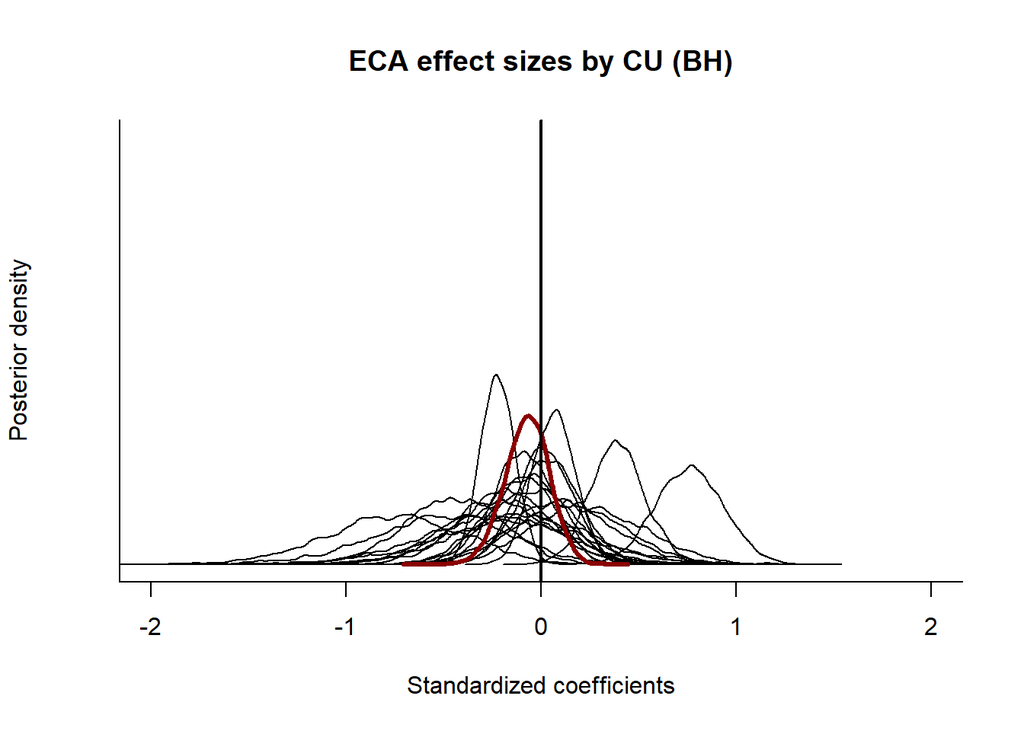

and alternatively with the Ricker model form:

```
##        variable         mean         sd          q5          q95     rhat
## 1         b_ECA -0.027092955 0.04065800 -0.09549448  0.038683470 1.007751
## 2   b_ECA_cu[1] -0.066753704 0.04068196 -0.13557120 -0.001275452 1.003029
## 3   b_ECA_cu[2] -0.025276123 0.08619242 -0.16978240  0.116643500 1.004528
## 4   b_ECA_cu[3]  0.060328178 0.11970760 -0.10191635  0.282534850 1.004892
## 5   b_ECA_cu[4] -0.073733069 0.11362821 -0.27875440  0.088511255 1.004456
## 6   b_ECA_cu[5] -0.024807233 0.05855138 -0.12162550  0.071879380 1.002656
## 7   b_ECA_cu[6]  0.050560876 0.10486290 -0.09555334  0.243923850 1.006728
## 8   b_ECA_cu[7]  0.012618015 0.07684509 -0.10698655  0.146527350 1.008384
## 9   b_ECA_cu[8] -0.005332835 0.07949787 -0.13058985  0.133839050 1.003697
## 10  b_ECA_cu[9]  0.136064051 0.11382929 -0.03088164  0.339310550 1.017534
## 11 b_ECA_cu[10]  0.010708191 0.04515833 -0.06081815  0.087537900 1.006002
## 12 b_ECA_cu[11] -0.044121998 0.06371302 -0.15000285  0.057518005 1.004147
## 13 b_ECA_cu[12] -0.094905707 0.06256060 -0.19840035  0.003071294 1.005052
## 14 b_ECA_cu[13] -0.113889519 0.11202314 -0.31942140  0.036007700 1.007256
## 15 b_ECA_cu[14] -0.051981220 0.09760033 -0.22297095  0.097414930 1.002779
## 16 b_ECA_cu[15] -0.043800529 0.13195835 -0.27076080  0.159570700 1.004820
## 17 b_ECA_cu[16] -0.008074969 0.10560656 -0.17222660  0.174210150 1.004512
## 18 b_ECA_cu[17]  0.037737974 0.11709302 -0.12751555  0.250380200 1.004741
## 19 b_ECA_cu[18] -0.135012249 0.13897236 -0.40314460  0.042834110 1.005706
## 20 b_ECA_cu[19] -0.056455115 0.09734761 -0.22634560  0.094559820 1.004559
## 21 b_ECA_cu[20] -0.016795702 0.12374377 -0.21195930  0.191746200 1.008204
## 22 b_ECA_cu[21] -0.052276719 0.09684027 -0.22487995  0.095956925 1.007345
## 23 b_ECA_cu[22] -0.104321923 0.13881247 -0.36631975  0.077831355 1.004239
```

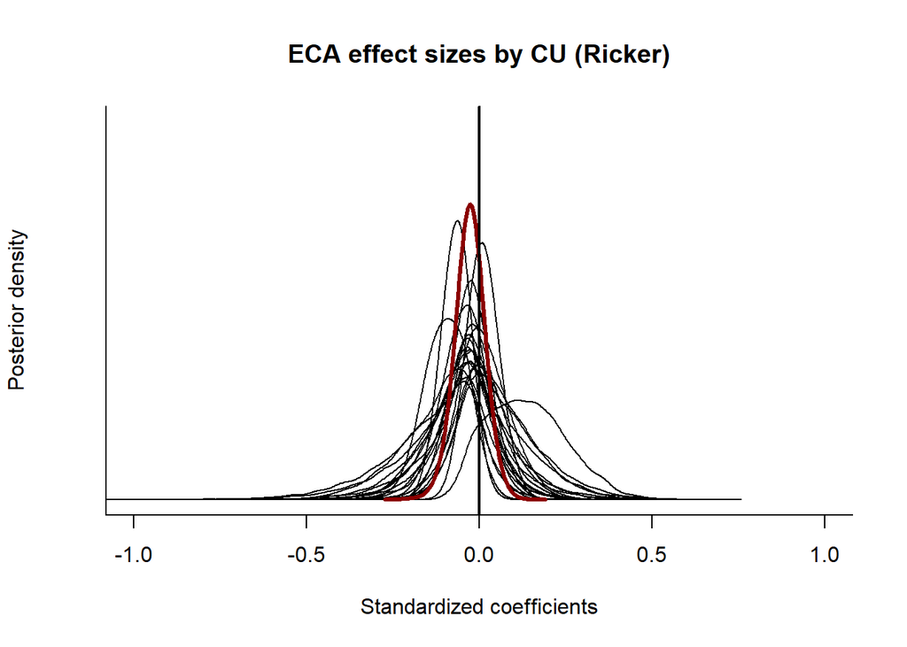

Visualized (back converted from logit scale to original ECA) for the Beverton-Holt model:

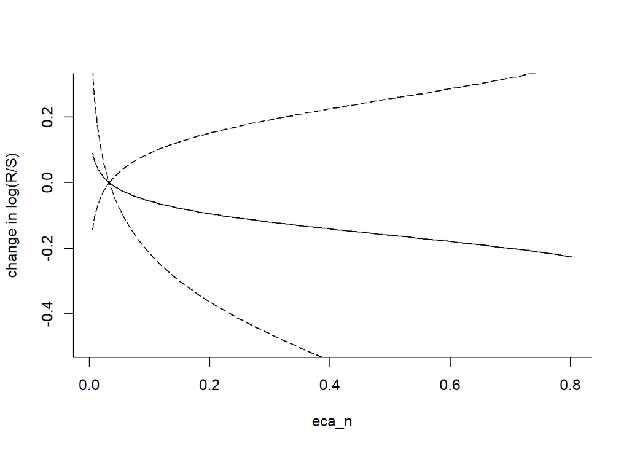

And Ricker model:

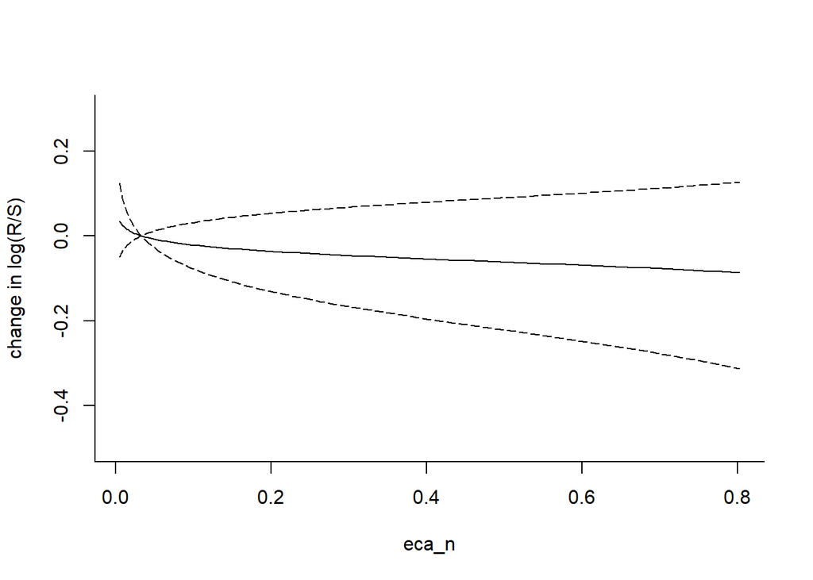

## 4.2 Fitset 2: River-level varying effects

The overall among population effect size (b_ECA) for ECA, and varying effects of ECA by CU (b_ECA_cu), from the Beverton-Holt fit.

This plot shows density of effect sizes among CUs and the red line indicates the global effect:

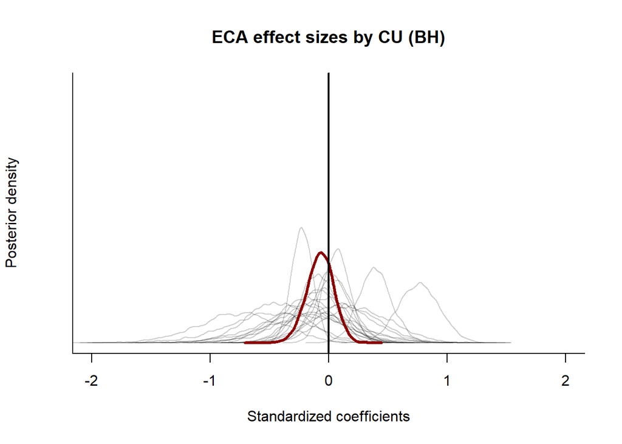

This plot shows density of effect sizes among Rivers and the red line indicates the global effect:

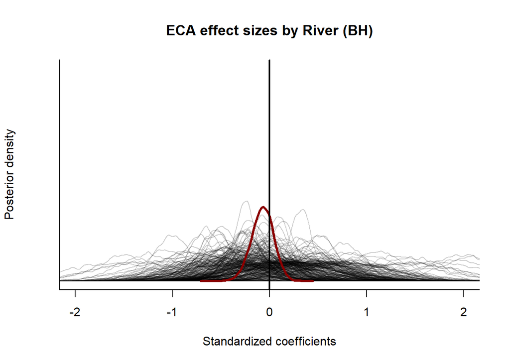

The realized function for ECA on productivity (in BH form):

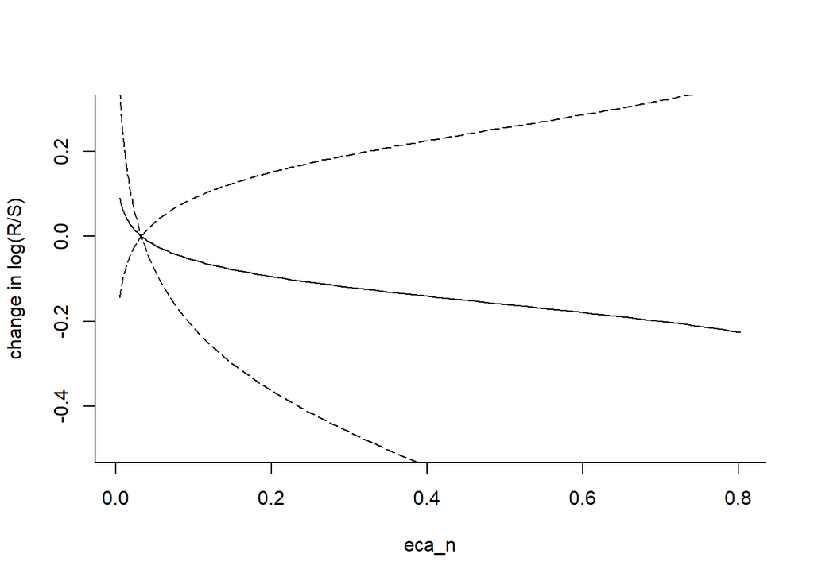

ECA effects with the Ricker model form at each hierarchical level:

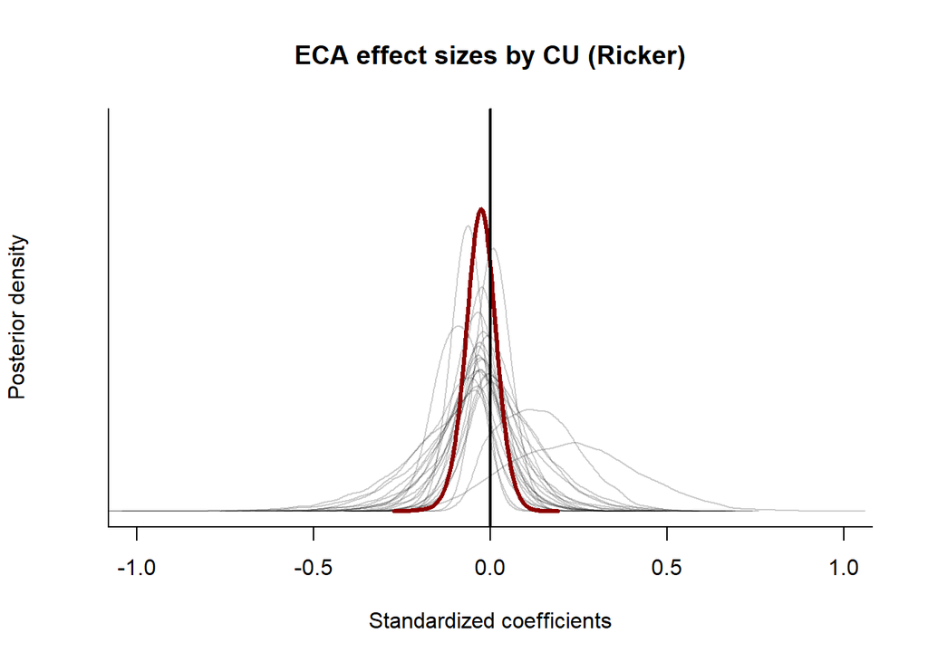

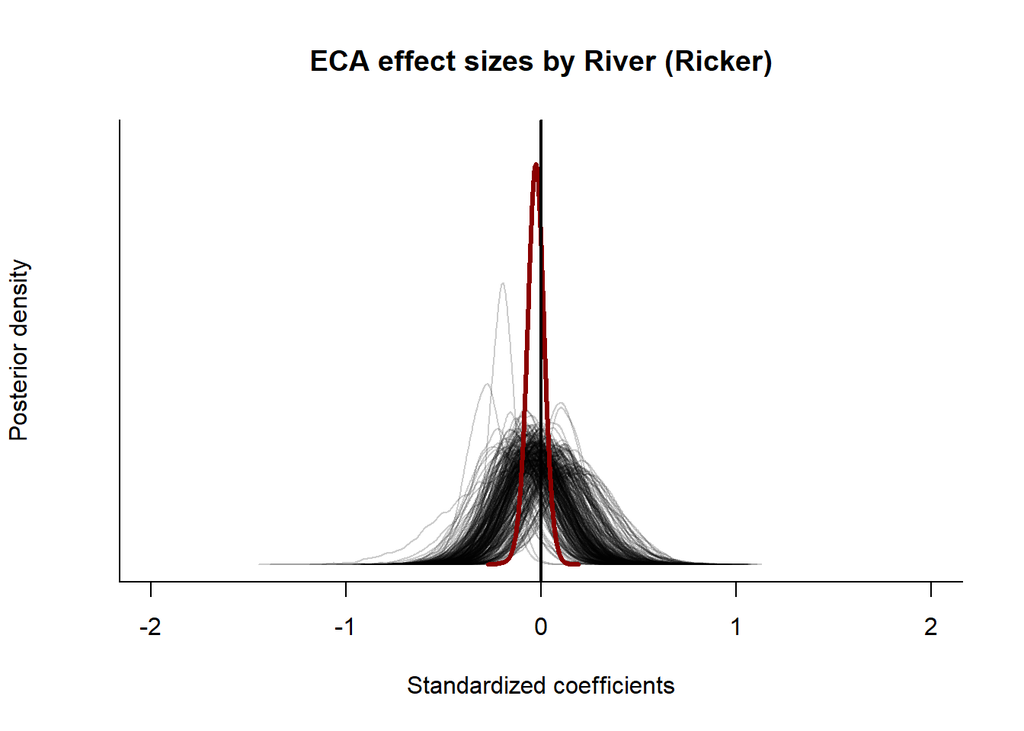

And Ricker model:

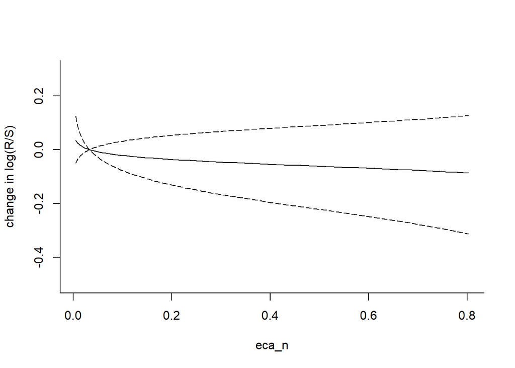

## 4.3 Fitset 3: Watershed area as a mediator

The third set of models includes watershed area as a mediator of the effect of ECA on productivity:

$log(R_{t,r}/S_{t,r}) = \alpha_r - \beta_r*S_{t,r} + \beta_{eca,c}*ECA_{t,r} + \beta_{eca_x_area,c}*ECA_{t,r}*Area_{r} + w_{t,r}$

This is the distribution of watershed area among 293 rivers included in this analysis:

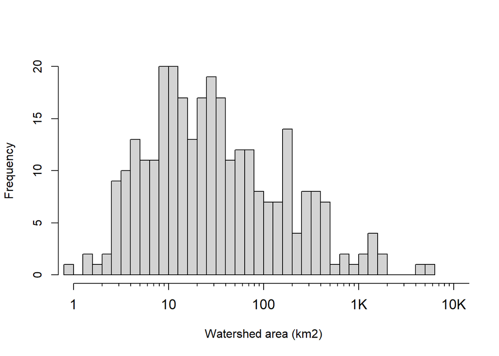

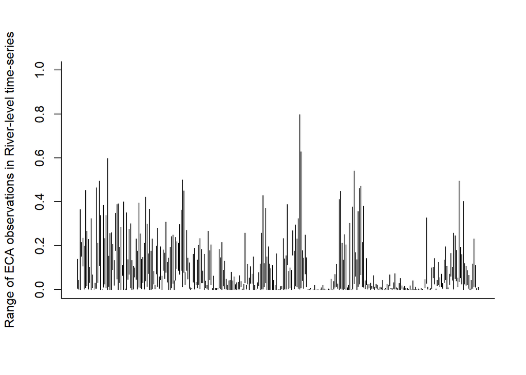

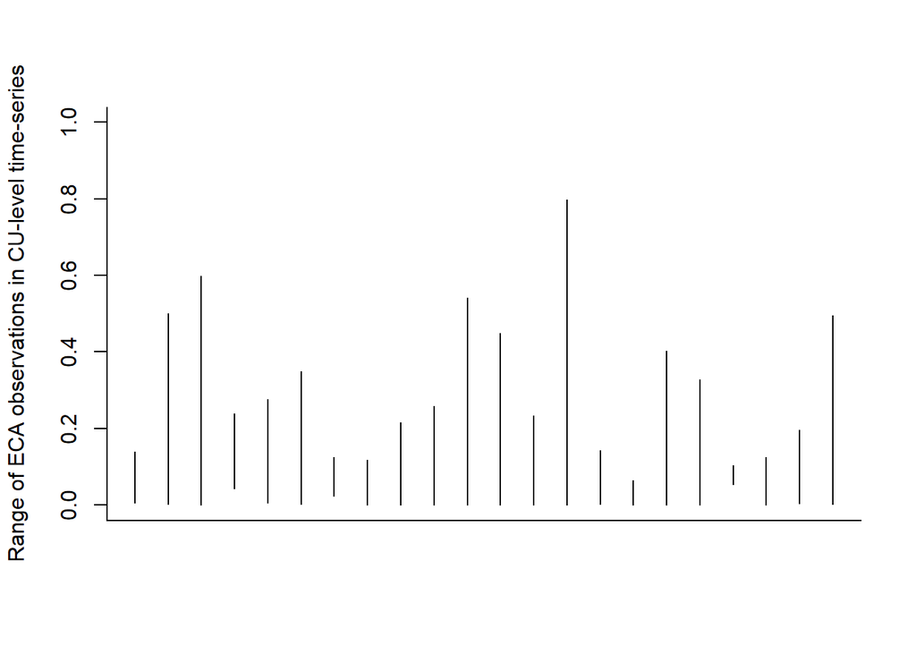

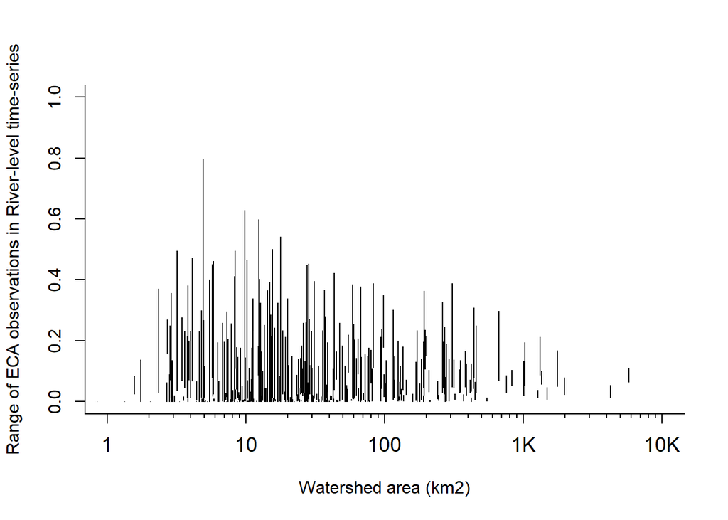

Beverton-Holt model with watershed area as a mediator of ECA:

```
##        variable        mean         sd          q5           q95      rhat
## 1         b_ECA -0.12614223 0.09751619 -0.28863395  0.0296641200 1.0017815
## 2   b_ECA_cu[1] -0.21800143 0.03936762 -0.28311665 -0.1533518000 1.0008695
## 3   b_ECA_cu[2] -0.10551461 0.12033646 -0.30699625  0.0953733700 1.0009015
## 4   b_ECA_cu[3]  0.22267992 0.21897759 -0.13285475  0.5855526500 1.0006266
## 5   b_ECA_cu[4] -0.98367313 0.24880598 -1.39034650 -0.5738139500 1.0003037
## 6   b_ECA_cu[5]  0.09478251 0.07544013 -0.02944405  0.2179888000 1.0053707
## 7   b_ECA_cu[6] -0.11764603 0.13387193 -0.33328405  0.1030428500 1.0014551
## 8   b_ECA_cu[7]  0.21390181 0.09762897  0.05177364  0.3771707500 1.0036408
## 9   b_ECA_cu[8] -0.06058841 0.10535929 -0.23288370  0.1118388000 1.0008983
## 10  b_ECA_cu[9]  0.77661413 0.13443686  0.55482735  0.9959731000 1.0006952
## 11 b_ECA_cu[10] -0.19147151 0.05304854 -0.27849670 -0.1039019500 1.0013576
## 12 b_ECA_cu[11] -0.05717912 0.07177537 -0.17526245  0.0616235900 1.0008256
## 13 b_ECA_cu[12] -0.17450998 0.05797762 -0.26925685 -0.0781682200 1.0014265
## 14 b_ECA_cu[13] -0.30625710 0.11529776 -0.49518725 -0.1172738500 1.0008295
## 15 b_ECA_cu[14]  0.10055319 0.21908674 -0.25754050  0.4537161500 1.0004271
## 16 b_ECA_cu[15] -0.23427334 0.41491090 -0.94378165  0.4321362000 1.0003407
## 17 b_ECA_cu[16] -0.02453385 0.19267154 -0.34200145  0.2865813000 0.9998736
## 18 b_ECA_cu[17]  0.19677397 0.21229443 -0.13894950  0.5509134000 1.0008740
## 19 b_ECA_cu[18] -0.68973793 0.26746708 -1.14503400 -0.2678898000 1.0012884
## 20 b_ECA_cu[19] -0.50172610 0.16324493 -0.77480080 -0.2342191500 1.0010934
## 21 b_ECA_cu[20] -0.11635263 0.33781465 -0.66652635  0.4372704500 1.0003648
## 22 b_ECA_cu[21] -0.13976650 0.17511130 -0.43591275  0.1481772000 1.0008024
## 23 b_ECA_cu[22] -0.45944519 0.27457470 -0.91751645 -0.0063115140 1.0004757
## 24   b_ECA_Area -0.04949919 0.03061452 -0.10047180  0.0009545121 1.0021590
```

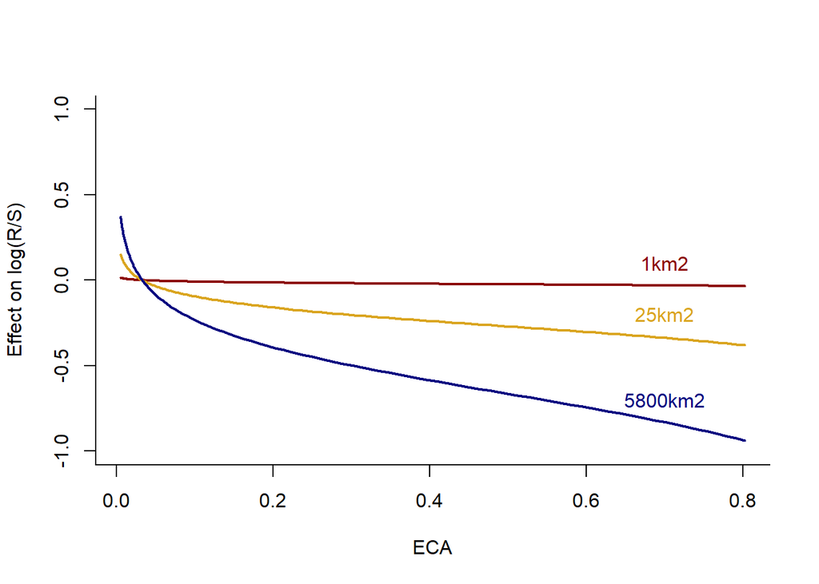

## 4.4 Non-linear effect of ECA

To explore if there were any signs of strong non-linear patterns in how ECA affects forestry we implemented an approach equivalent to a Generalized Additive Model (GAM). We use a matrix of B-splines with 6 knots that subdivide the predictor (ECA), the resulting estimated effect of ECA at any given point is the sum of these smoothed functions. The global function of ECA effects on productivity fit to all rivers/CUs”

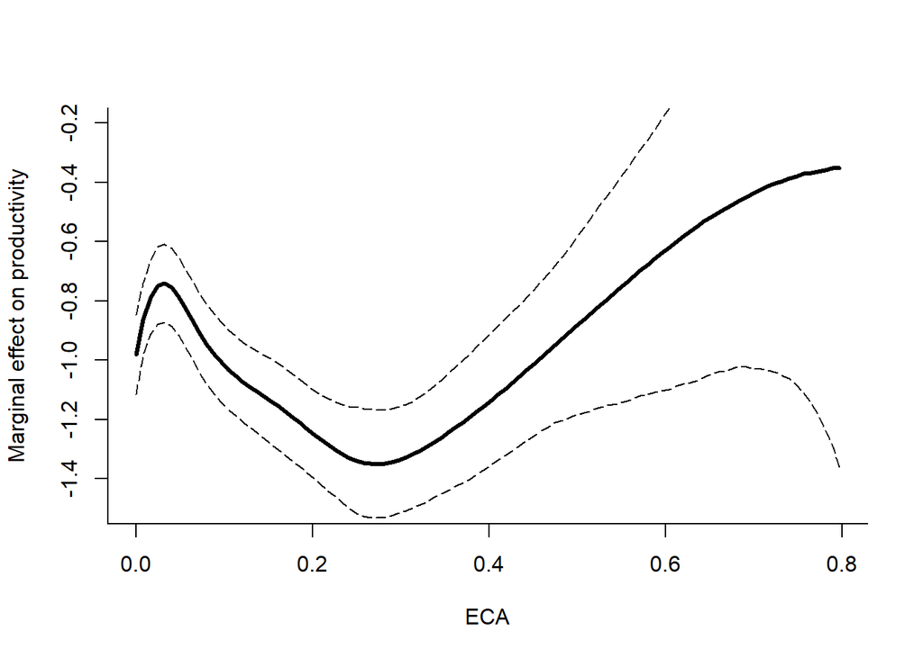

# 5 ECA and effect size time-series - Beverton Holt

Overall distribution of ECA among all observations:

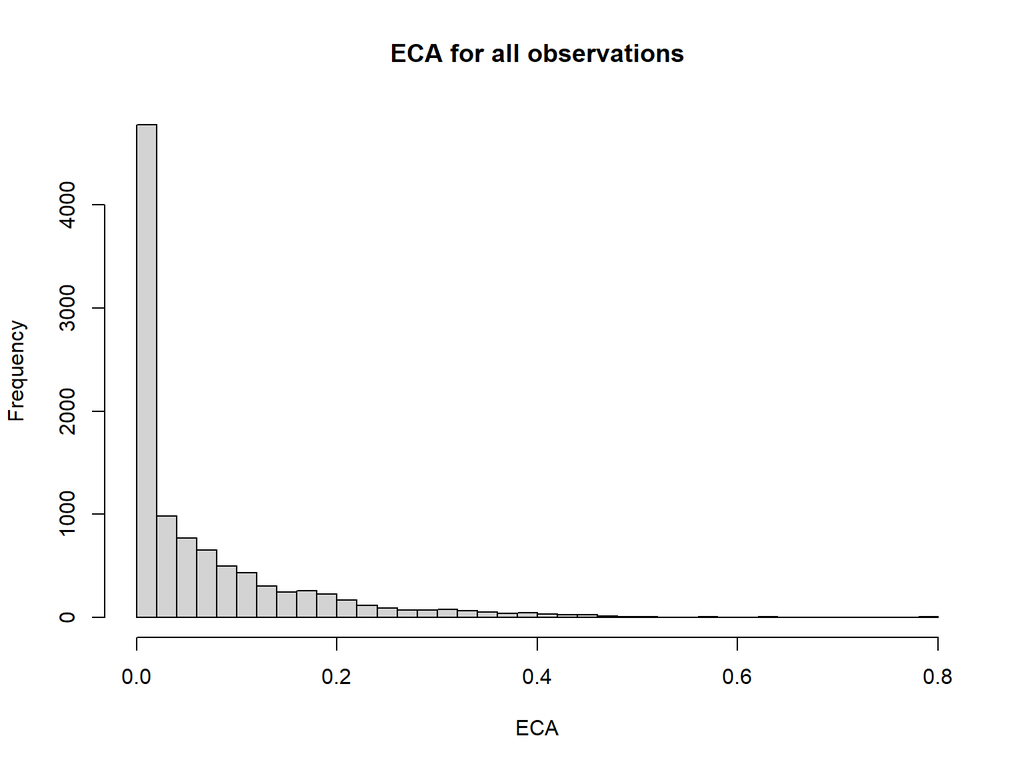

River-level ECA and effect on productivity through time by CU (BH model):

## 5.1 CM-10

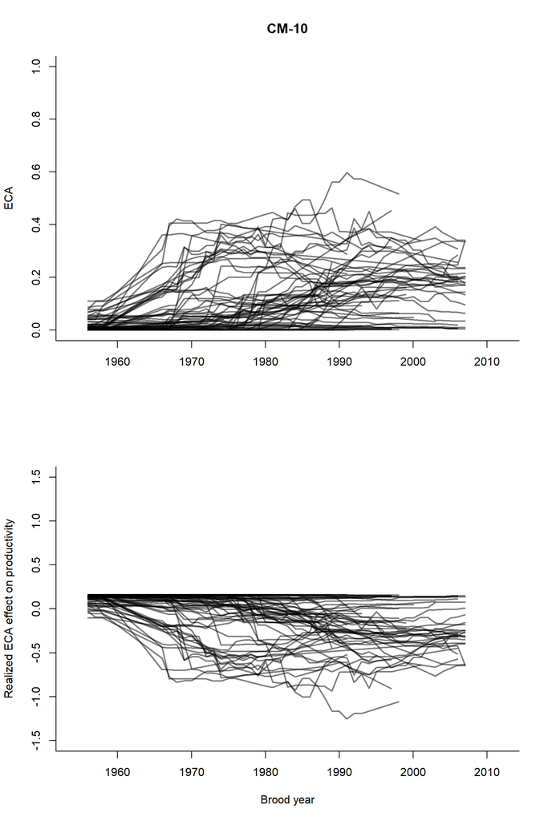

## 5.2 CM-11

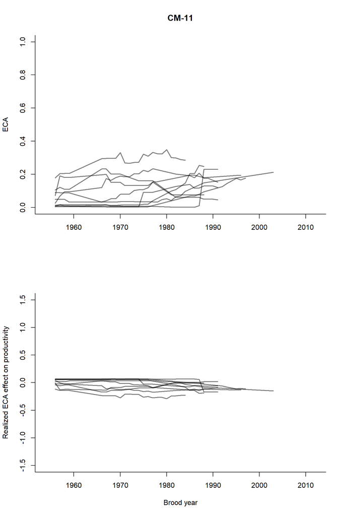

## 5.3 CM-12

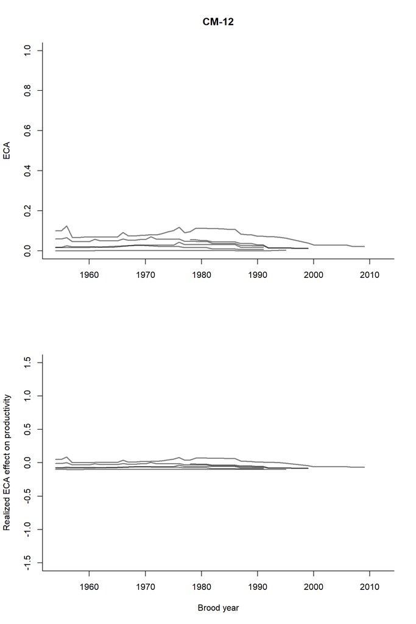

## 5.4 CM-13

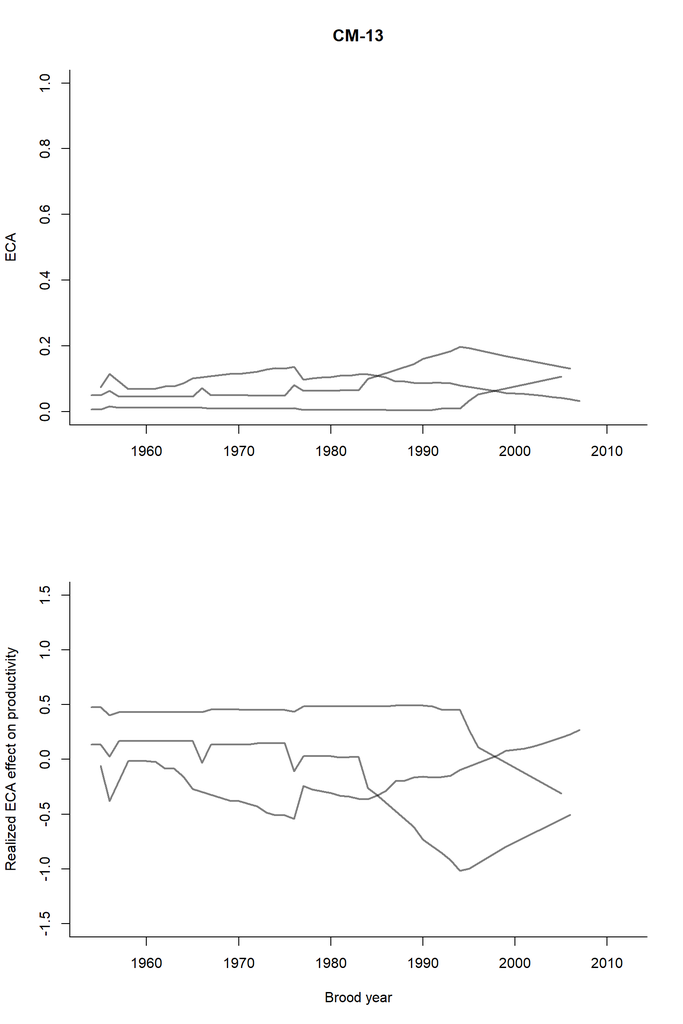

## 5.5 CM-15

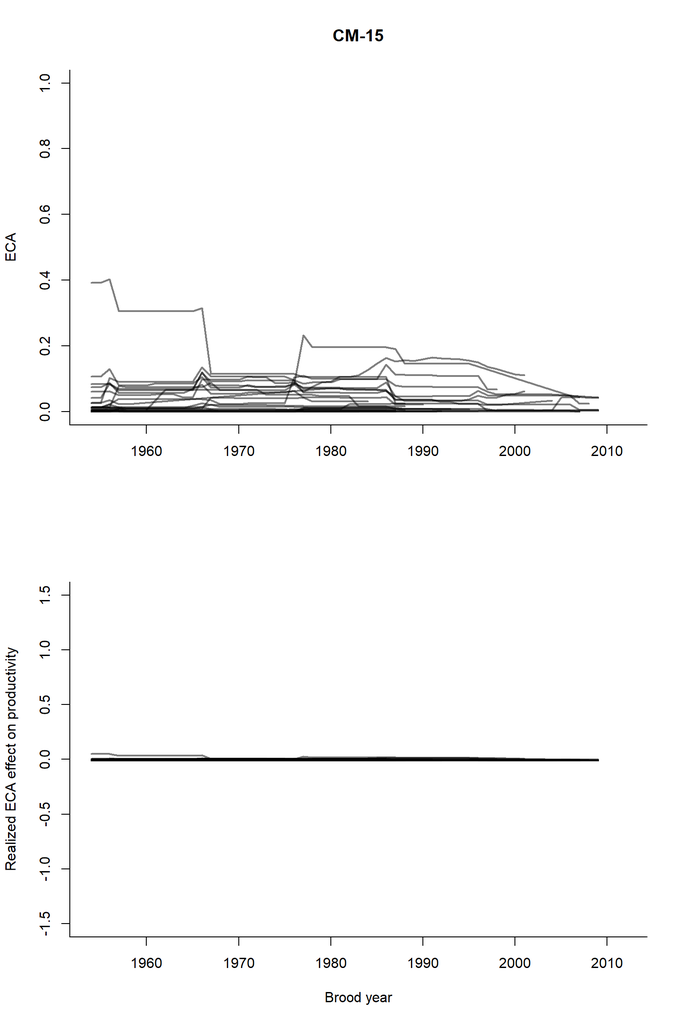

## 5.6 CM-16

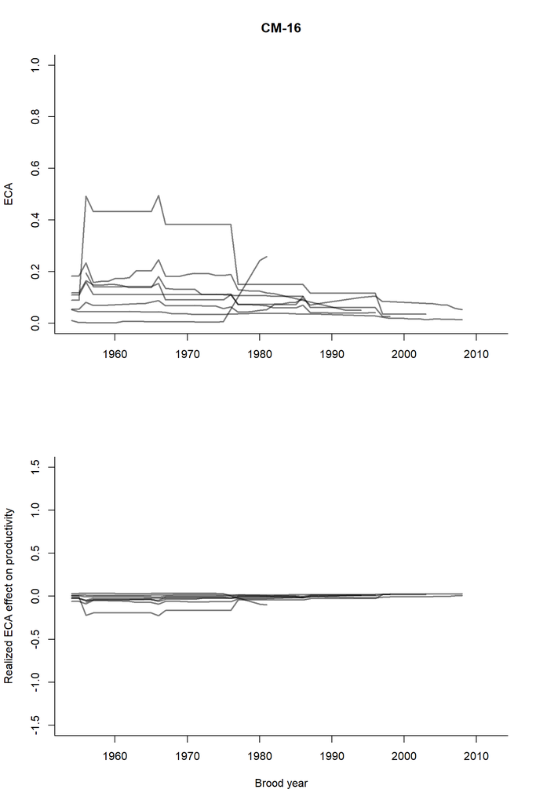

## 5.7 CM-18

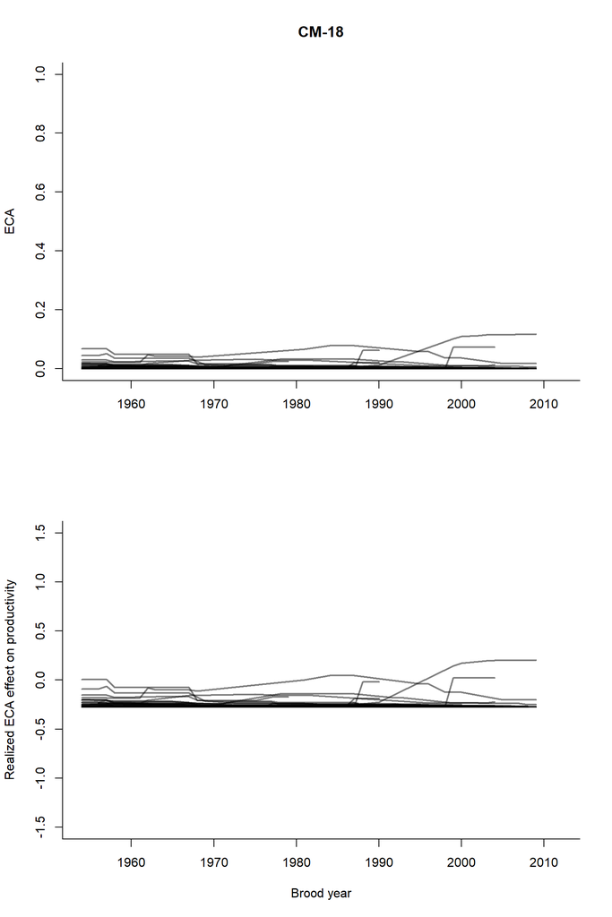

## 5.8 CM-19

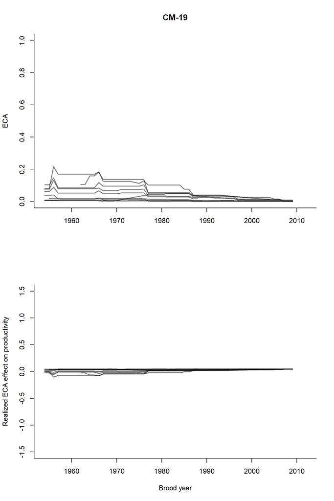

## 5.9 CM-20

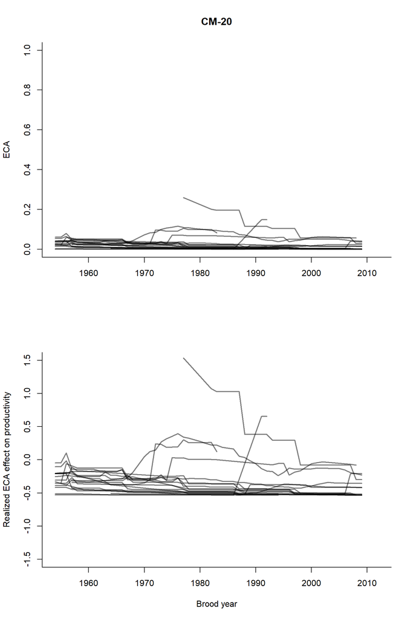

## 5.10 CM-21

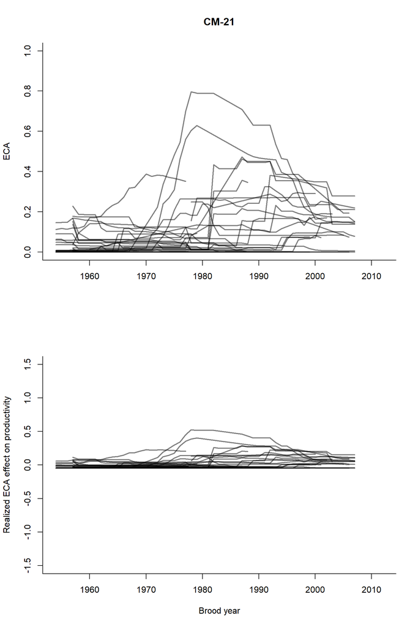

## 5.11 CM-22

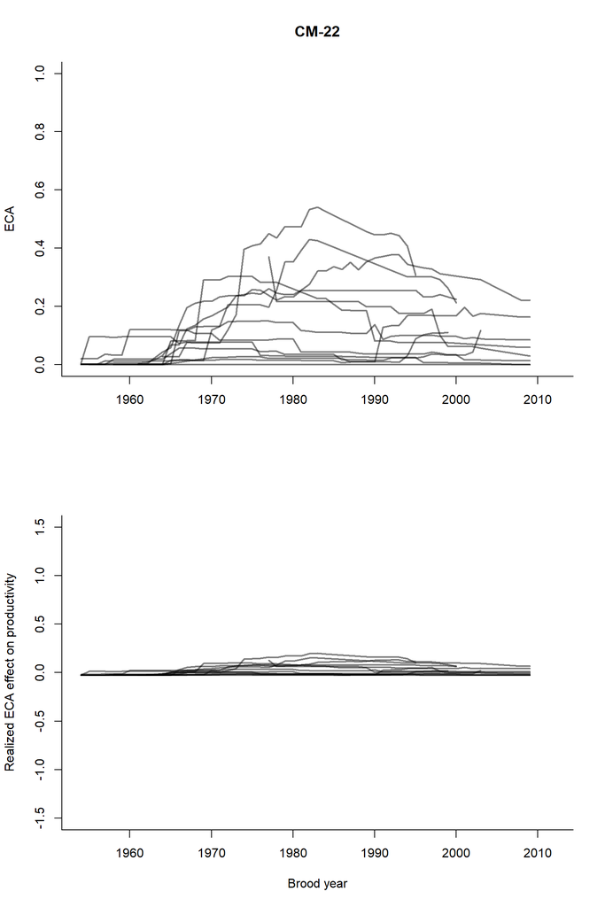

## 5.12 CM-23

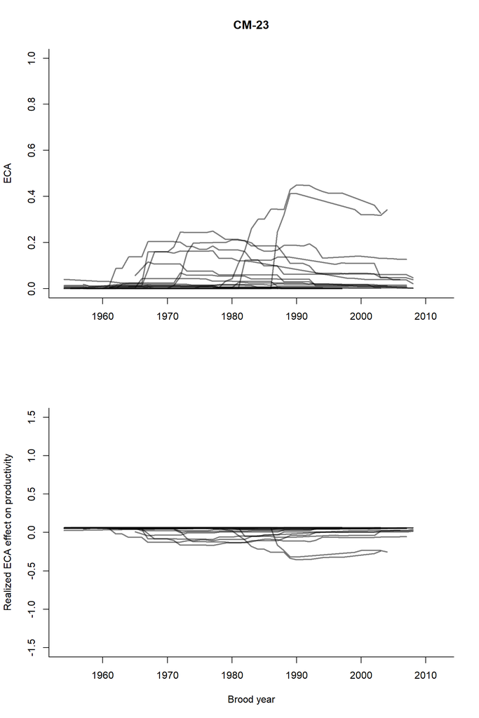

## 5.13 CM-24

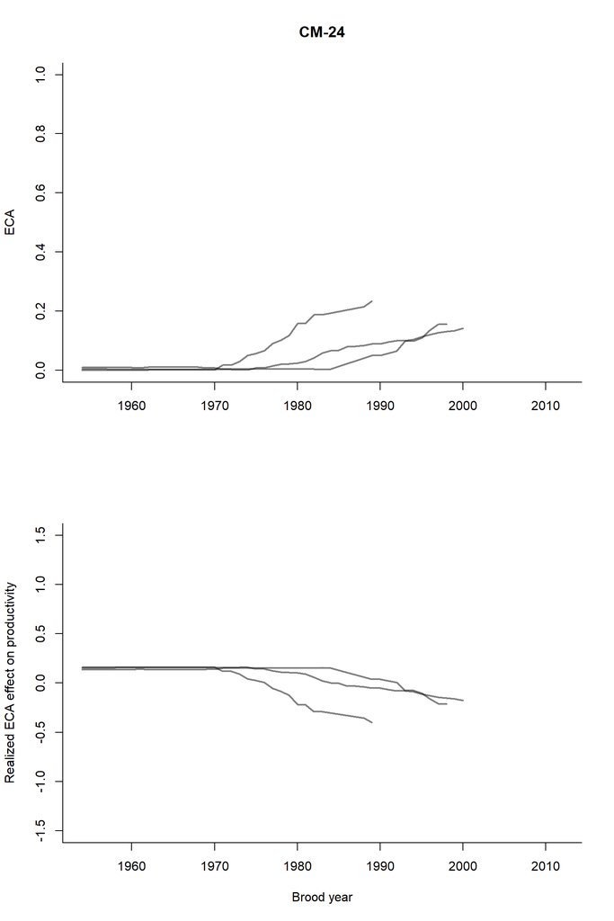

## 5.14 CM-27

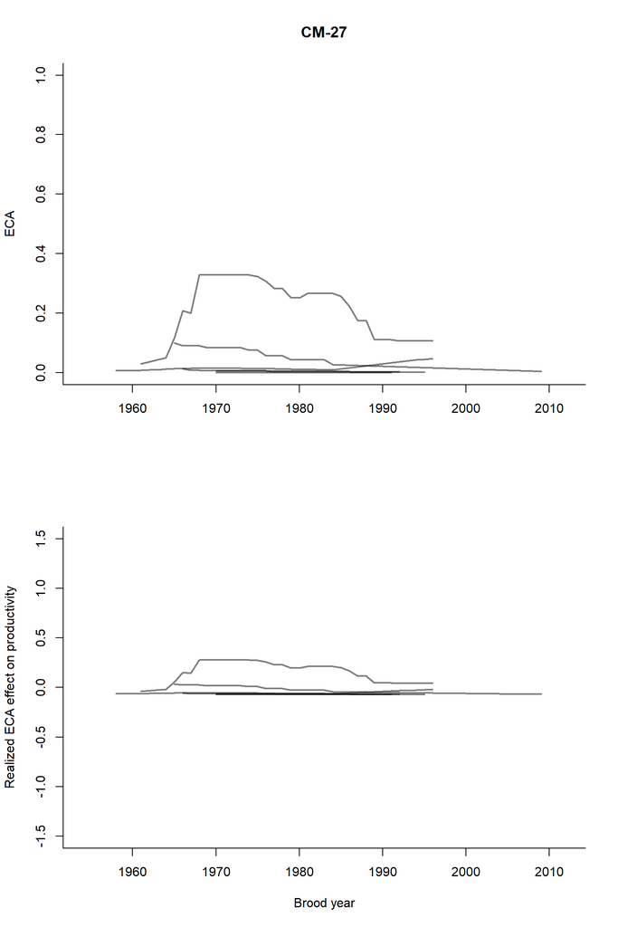